# Sieci Bayesowskie

Paweł Drozd

Styczeń, 2020

### Czym są sieci bayesowskie?

Za [wikipedią](https://en.wikipedia.org/wiki/Bayesian_network):

> A Bayesian network (…) is a probabilistic **graphical model** (a type of statistical model) that represents a set of variables and their **conditional dependencies** via a **directed acyclic graph (DAG)**.

Teraz rozłóżymy tę definicję na mniejsze części:

- graphical model: oznacza tyle, że model będzie w postaci grafu
- DAG: graf (model) nie może być dowolny. Musi być skierowany i acykliczy

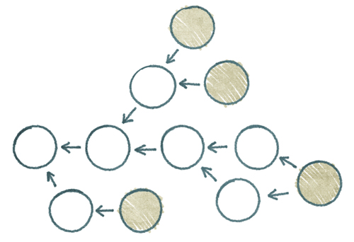

- conditional dependencies: sedno modelu. Wierzchołki grafu odpowiadają zmienny, krawędzie reprezentują warunkowe zleżności między zmiennymi.

### Do czego mogą służyć?

1. Ustalenie zależności między zmiennym.
2. Wizualizacja tych zależności.
3. Wnoskowanie na temat obserwaji.
4. Uzupełnianie danych.

### Jak zbudować?

Skoro mniej więcej wiemy czym są te modele, stwórzmy jakiś. Wykorzystamy dane na temat tego jak wybrane charakterystyki krwi zmieniają się wraz z płcią i sportem uprawianym przez zawodników. Ogarniczymy się do 6 zmiennych:

- płeć
- sport
- pcBfat - procent tkanki tłuszczowej
- hg - stężenie hemoglobiny
- rcc - liczba czerwonych krwinek
- hc - procentowy hematokryt

```r
library(bnlearn)
library(tidyverse)
library(visNetwork)
library(DAAG)

data('ais')

ais_sub <- ais %>%
  select(sex, sport, pcBfat, hg, rcc, hc)

skimr::skim(ais_sub) %>% skimr::kable()
```

```
## Skim summary statistics
##  n obs: 202
##  n variables: 6
##
## Variable type: factor
##
##  variable    missing    complete     n     n_unique                top_counts                ordered
## ----------  ---------  ----------  -----  ----------  ------------------------------------  ---------
##    sex          0         202       202       2              m: 102, f: 100, NA: 0            FALSE
##   sport         0         202       202       10       Row: 37, T_4: 29, B_B: 25, Net: 23     FALSE
##
## Variable type: numeric
##
##  variable    missing    complete     n     mean      sd      p0     p25      p50      p75     p100       hist
## ----------  ---------  ----------  -----  -------  ------  ------  ------  -------  -------  -------  ----------
##     hc          0         202       202    43.09    3.66    35.9    40.6    43.5     45.58    59.7     ▅▆▇▇▂▁▁▁
##     hg          0         202       202    14.57    1.36    11.6    13.5    14.7     15.57    19.2     ▂▆▆▇▇▁▁▁
##   pcBfat        0         202       202    13.51    6.19    5.63    8.54    11.65    18.08    35.52    ▇▅▂▅▂▁▁▁
##    rcc          0         202       202    4.72     0.46    3.8     4.37    4.75     5.03     6.72     ▃▇▆▇▂▁▁▁
```

Tworzenie modelu odbyć się może na dwa sposoby. W pierwszym samodzielnie definiujemy zależności między zmiennymi. Drugie podejście pozwala na automatyczne określenie struktury grafu.

Przykład samodzielnego definiowania.

```r
bn_struktura <- model2network("[sex][sport|sex][hg|sex][pcBfat|hg:sex:sport][hc|hg][rcc|hc]")

bn_struktura
```

```
##
##   Random/Generated Bayesian network
##
##   model:
##    [sex][hg|sex][sport|sex][hc|hg][pcBfat|hg:sex:sport][rcc|hc]
##   nodes:                                 6
##   arcs:                                  7
##     undirected arcs:                     0
##     directed arcs:                       7
##   average markov blanket size:           2.67
##   average neighbourhood size:            2.33
##   average branching factor:              1.17
##
##   generation algorithm:                  Empty
```

```r
plot_network(bn_struktura)
```

[interactive chart not shown]

Drugim podejściem jest pozostawienie stworzenia grafu algorytmowi. Jeśli chcemy możemy w ten proces do pewnego stopnia ingerować, definiując krawędzie, które muszą lub nie mogą się pojawić.

```r
bn_struktura <- hc(ais_sub, score = "bic-cg")

plot_network(bn_struktura)
```

[interactive chart not shown]

W dalszej części, będziemy posługiwać się modelem stworzonym automatycznie. Kolejnym krokiem jest estymacji warunkowych rozkładów poszczególych zmiennych.

```r
bn_model <- bn.fit(bn_struktura, ais_sub)
```

Właściwie, to model jest gotowy do użycia :) Co można z nim zrobić poza narysowaniem ładnych grafów? Po pierwsze odpytać.

Być może interesuje nas jakie jest prawdopodobieństo, że mężczyzna uprawijący pływanie będzie miał ponad 10% tkanki tłuszczowej?

```r
cat("P(pcBfat > 10 | mężczyzna i pływa) =", cpquery(bn_model, (pcBfat > 10), (sport == "Swim" & sex == 'm')))
```

```
## P(pcBfat > 10 | mężczyzna i pływa) = 0.1380323
```

Zapytania mnie muszą być formułowanie wyłącznie w kierunku krawędzi grafu.

```r
cat("P(kobieta | gra w koszykówkę i hg > 10) =", cpquery(bn_model, (sex == 'f'), (sport == "B_Ball" & hg > 10)))
```

```
## P(kobieta | gra w koszykówkę i hg > 10) = 0.5323575
```

Możemy też pomijać, niektóre wierzchołki (zmienne).

```r
cat("P(sprint | hc > 16 i pcBfat > 7) =", cpquery(bn_model, (sport == 'T_Sprnt'), (hc > 16 & pcBfat > 7)))
```

```
## P(sprint | hc > 16 i pcBfat > 7) = 0.05449309
```

Co dalej? W zaproszeniu napisałem o uzupełnianiu danych. Skoro znamy rozkłady warunkowe poszczególnych zmiennych, wydaje się, że uzyskanie wartości dla kilku pustych zmiennych nie powinno być problemem. Dokładnie tak jest.

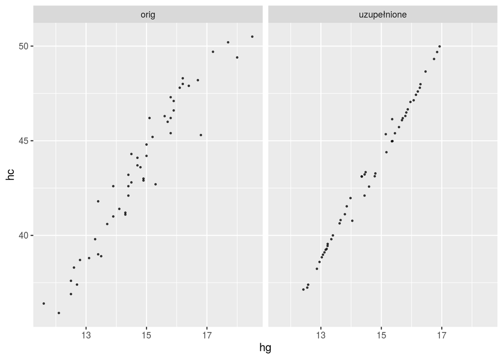

```r
ais_miss <- ais_sub
miss_id <- sample(1:nrow(ais_sub), 50)
ais_miss[miss_id, c("hg", "hc")] <- NA


ais_imp <- impute(bn_model, data = ais_miss, method = "bayes-lw")

ais_comb <- ais_sub %>%
  slice(miss_id) %>%
  mutate(set = 'orig') %>%
  bind_rows(ais_imp %>%
            slice(miss_id) %>%
              mutate(set = 'uzupełnione'))


ggplot(ais_comb) +
  geom_point(aes(x = hg, y = hc), alpha = 0.7, size = 0.5) +
  facet_grid(cols = vars(set))
```

Oczywiście, można uzupełnić więcej niż dwie zmienne. W związku z tym zasadne wydaje się pytanie ile minimalnie wartości musi być znane, aby to uzupełnianie dało się wykonać?

Odpowiedzą jest: 0. Po wytrenowaniu modelu, kiedy znane znane są probabilistyczne zależności między zmiennymi, możemy symulować całe zbiory danych.

```r
ais_sim <- rbn(bn_model, 202)

ais_comb <- ais_sub %>%
  mutate(set = 'orig') %>%
  bind_rows(ais_sim %>%
              mutate(set = 'sim')) %>%
  mutate(set = as.factor(set))
```

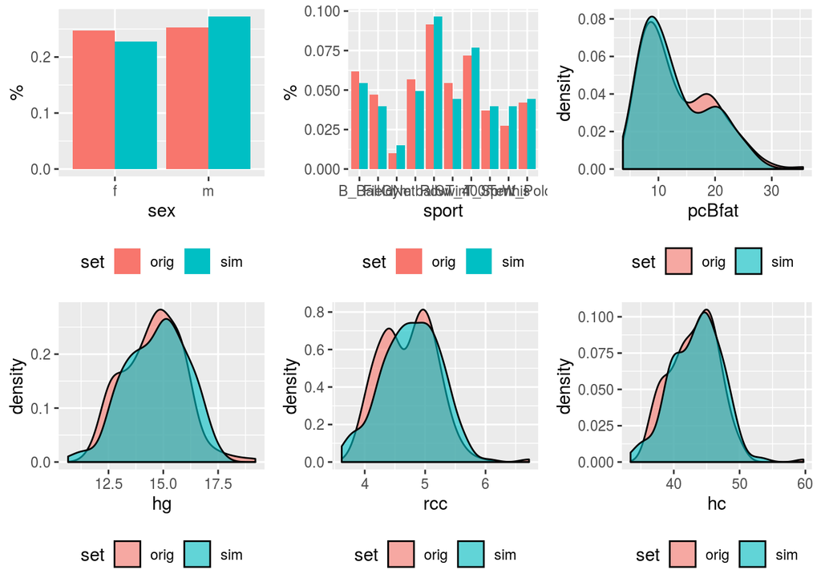

Nie wygląda to najgorzej :)

### Źródła

1. [Strona paczki implementującej sieci](https://www.bnlearn.com/)
2. “Bayesian Networks in R with Applications in Systems Biology”, R. Nagarajan, M. Scutari and S. Lèbre (2013).